# r_graph

SeokRae

2018년 4월 22일

# 1 Graph(그래프)

```
 - 그래픽스 기능 (graphics, lattice, ggplot)
 - 파라미터를 중점으로 공부
```

> graphics

```
 - R의 가장 기본이되는 시작화 기능
 - 전체 함수의 목록은 library(help='graphics')를 통해 알 수 있다.
```

## 1.1 산점도

- 주어진 데이터를 점으로 표시해 흩뿌리듯이 시각화한 그림이다.
- plot()은 산점도 뿐만 아니라 일반적으로 객체를 시각화하는데 모두 사용될 수 있는 일반함수(Generic Function)이다.
- 여기서 일반 함수란 주어진 데이터 타입에 따라 다른 종류의 plot() 함수의 변형이 호출됨

```r
# plot()이 어떤 객체들을 그려줄 수 있는지 확인
methods("plot")
```

```
##  [1] plot.acf*           plot.data.frame*    plot.decomposed.ts*
##  [4] plot.default        plot.dendrogram*    plot.density*
##  [7] plot.ecdf           plot.factor*        plot.formula*
## [10] plot.function       plot.hclust*        plot.histogram*
## [13] plot.HoltWinters*   plot.isoreg*        plot.lm*
## [16] plot.medpolish*     plot.mlm*           plot.ppr*
## [19] plot.prcomp*        plot.princomp*      plot.profile.nls*
## [22] plot.raster*        plot.spec*          plot.stepfun
## [25] plot.stl*           plot.table*         plot.ts
## [28] plot.tskernel*      plot.TukeyHSD*
## see '?methods' for accessing help and source code
```

```
 plot.lm은 lm이라는 클래스에 정의된 plot 메소드로서 plot(lm 객체)와 같은 방식으로 호출하면 자동으로 lm 클래스의 plot이 불려지게 된다.
 plot()이 주어진 객체에 따라 다르게 처리된다.
```

- plot() 함수를 사용한 가장 빈번한 예는 산점도(scatter plot)을 그리는 것이다.
- mlbench 패키지에 있는 Ozone 데이터 사용

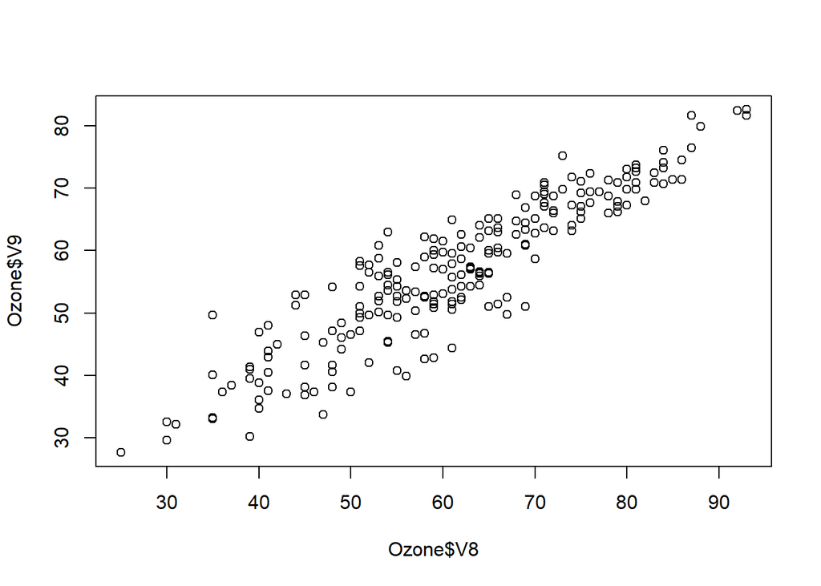

```r
# install.packages("mlbench")
library(mlbench)
# data()문은 mlbench 패키지 로딩뒤 Ozone 데이터 셋을 읽어들이기 위해 사용한 명령어
# 각 데이터는 data()문을 통해 읽어들일 수 있다.
data(Ozone)
# Ozone의 V8과 V9변수는 각각 캘리포니아 Sandburg와 El Monte에서 매일 측정한 온도이다.
plot(Ozone$V8, Ozone$V9)
```

> Ozone 정보

```
 Ozone 데이터에 들어있는 각 필드의 설명은 ?Ozone 또는 help(Ozone)명령으로 볼 수 있다.
 mlbench에 포함된 전체 데이터는 library(help = “mlbench”) 명령으로 살펴볼수 있다.
```

- plot은 (x, y) 순서로 입력을 받으며, x와 y가 숫자형 데이터의 경우 산점도를 그려준다.

## 1.2 그래픽 옵션

- plot()과 같은 그래픽 함수들은 여러가지 파라미터들로 그 모양을 다듬을 수 있다.
- 파라미터에 대한 리스트 확인

```r
# ?par
```

### 1.2.1 축 이름(xlab, ylab)

- x축, y축의 레이블이 컬럼명이므로 그 의미를 알 수 없다.
- 그래서 xlab, ylab으로 축이름을 지정

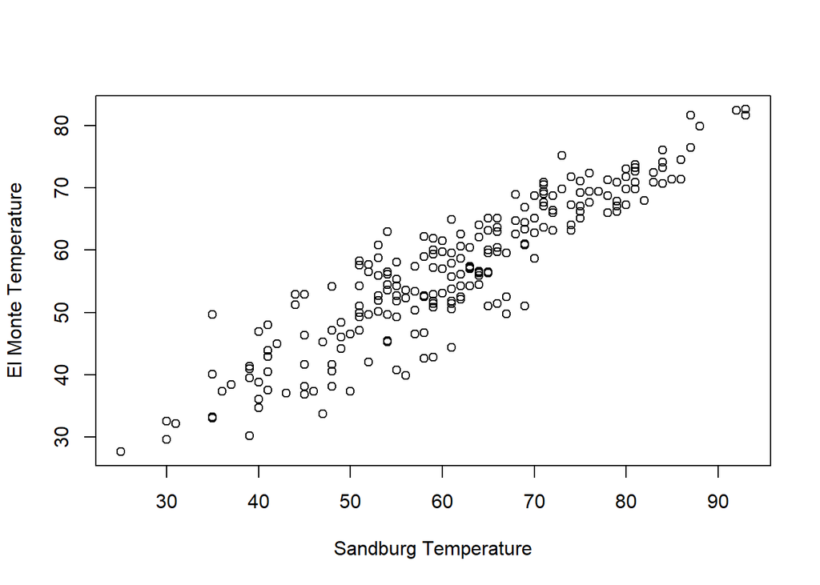

```r
plot(Ozone$V8,
     Ozone$V9,
     xlab="Sandburg Temperature",
     ylab="El Monte Temperature")
```

### 1.2.2 그래프 제목(main)

- 그래프에 제목을 붙이기 위해서는 main 파라미터로 지정해야 한다.

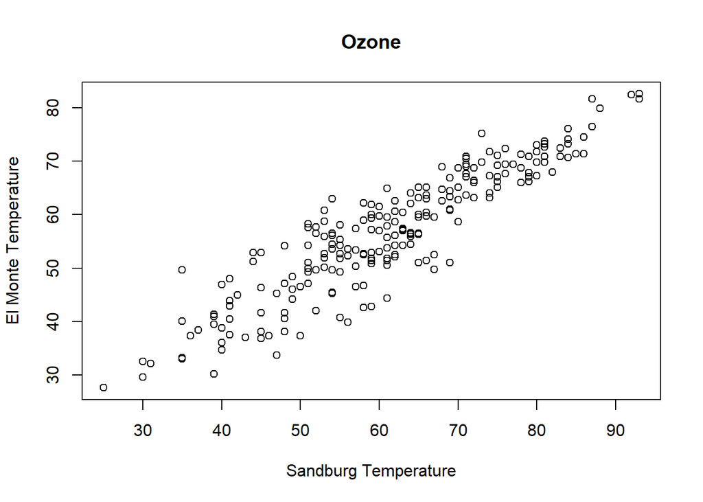

```r
plot(
  Ozone$V8,
  Ozone$V9,
  xlab="Sandburg Temperature",
  ylab="El Monte Temperature",
  main="Ozone"
)
```

### 1.2.3 점의 종류(pch)

- 그래프에 보이는 점의 모양은 pch로 지정
- pch에 숫자를 지정하면 미리 지정된 심볼이 사용
- 문자(예를 들어 ‘+’)를 지정하면 그 문자를 사용해 점을 표시한다.

```r
split.screen(c(1,2))
```

```
## [1] 1 2
```

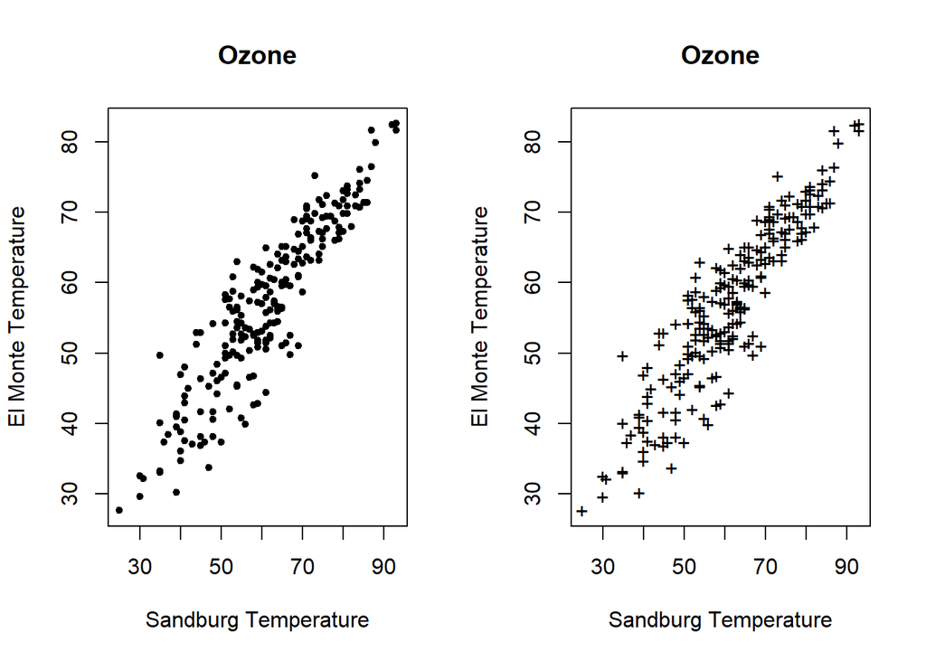

```r
screen(1)
plot(
  Ozone$V8,
  Ozone$V9,
  xlab="Sandburg Temperature",
  ylab="El Monte Temperature",
  main="Ozone",
  pch=20
)
screen(2)
plot(
  Ozone$V8,
  Ozone$V9,
  xlab="Sandburg Temperature",
  ylab="El Monte Temperature",
  main="Ozone",
  pch="+"
)
```

### 1.2.4 점의 크기(cex)

- 산점도에 보인 점의 크기는 cex로 조정할 수 있다.

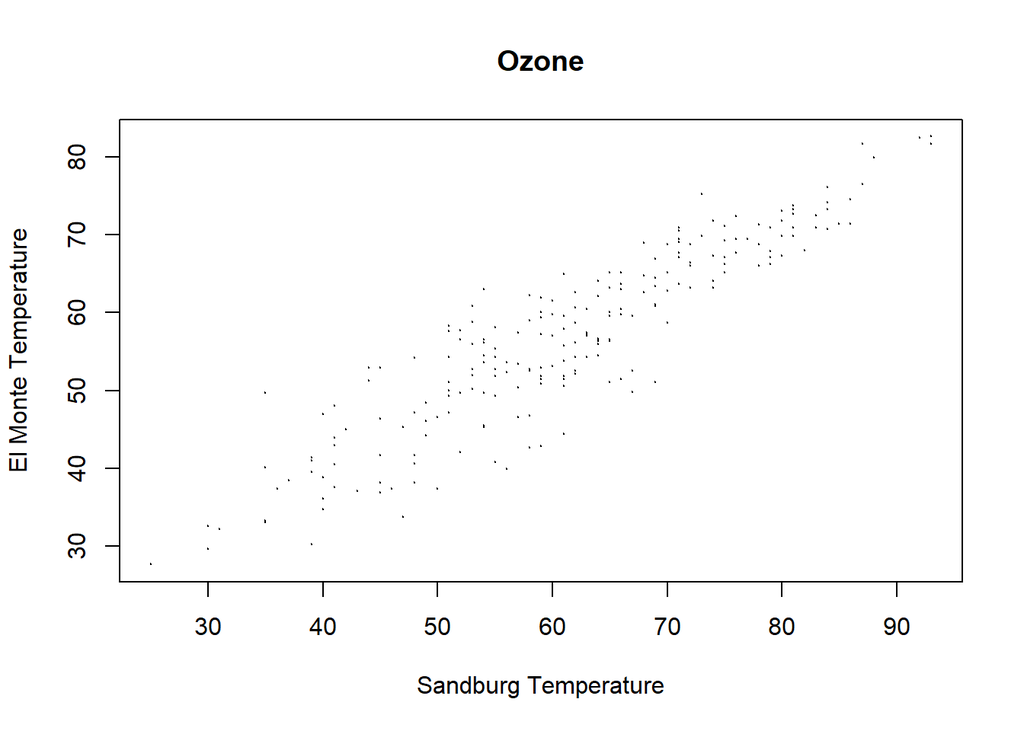

```r
plot(
  Ozone$V8,
  Ozone$V9,
  xlab="Sandburg Temperature",
  ylab="El Monte Temperature",
  main="Ozone",
  cex=.1
)
```

### 1.2.5 색상(col)

- 색상은 col 파라미터로 RGB 값을 각각 두자리씩 지정한다.
- 전체 색상 목록은 colors()명령으로 볼 수 있다.

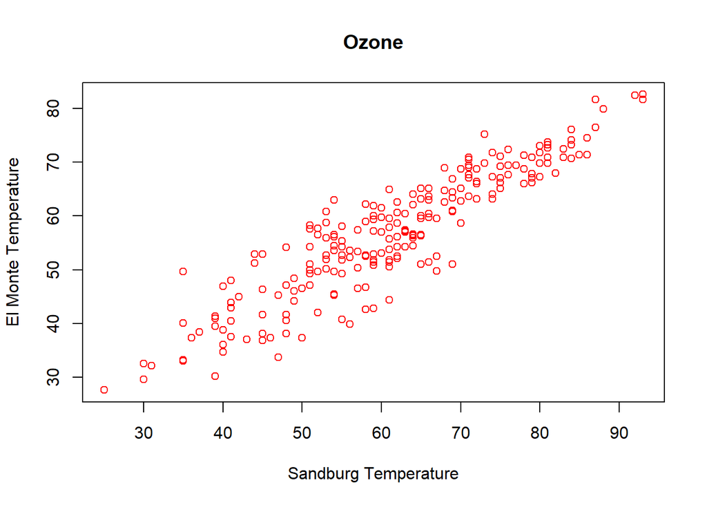

```r
plot(
  Ozone$V8,
  Ozone$V9,
  xlab="Sandburg Temperature",
  ylab="El Monte Temperature",
  main="Ozone",
  col="#FF0000"
)
```

- 이외에도 col.axis, col.lab 등의 옵션으로 그래프의 여러 부분에 색상 지정이 가능하다.

### 1.2.6 좌표축 값의 범위(xlim, ylim)

- 그래프에 그려질 x값의 범위, y값의 범위를 바꿀 수 있다.
- x축과 y축 각각 xlim, ylim을 사용하여 c(최솟값, 최댓값)의 형태로 각 인자에 값을 지정

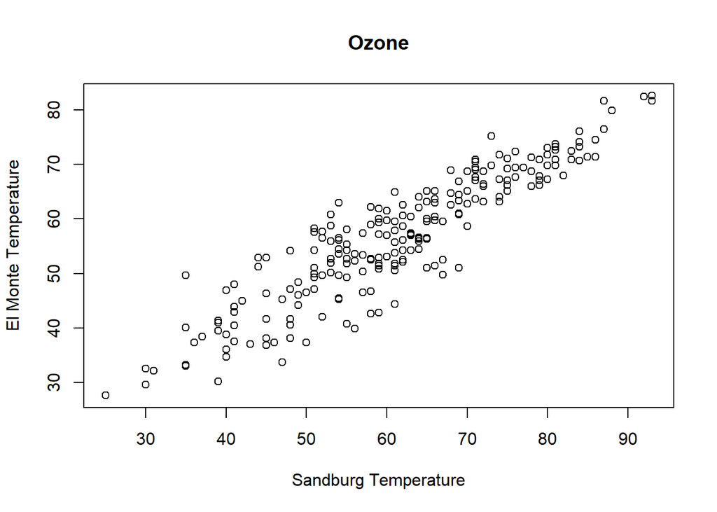

```r
plot(
  Ozone$V8,
  Ozone$V9,
  xlab="Sandburg Temperature",
  ylab="El Monte Temperature",
  main="Ozone"
)
```

```r
max(Ozone$V8) # 컬럼에 NA값이 있기 때문에 na.rm=TRUE속성을 지정해줘야한다.
```

```
## [1] NA
```

```r
max(Ozone$V8, na.rm=TRUE)
```

```
## [1] 93
```

```r
max(Ozone$V9, na.rm=TRUE)
```

```
## [1] 82.58
```

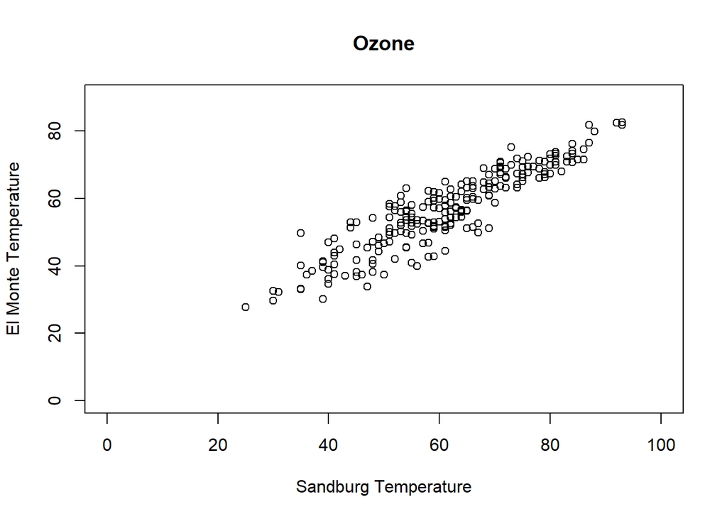

```r
plot(
  Ozone$V8,
  Ozone$V9,
  xlab="Sandburg Temperature",
  ylab="El Monte Temperature",
  main="Ozone",
  xlim=c(0, 100),
  ylim=c(0, 90)
)
```